# Part 1 Q1 Import the data. Analyse the dimensions of the data. Visualise the data.

```python
# Importing libraries

import cv2
import os
import numpy as np
import matplotlib as mp
import matplotlib.pyplot as plt
import seaborn as sns
import pandas as pd
from sklearn import svm, metrics
from natsort import natsorted
from mpl_toolkits.axes_grid1 import ImageGrid
import matplotlib.pyplot as plt
%matplotlib inline
import glob
from sklearn.model_selection import StratifiedKFold
from sklearn.ensemble import RandomForestClassifier
# from sklearn.grid_search import GridSearchCV
from sklearn.cluster import KMeans
from sklearn.preprocessing import LabelEncoder
from sklearn.model_selection import train_test_split
from sklearn.decomposition import PCA as RandomizedPCA
from sklearn.svm import SVC
from sklearn.model_selection import learning_curve, GridSearchCV
from tensorflow.keras.utils import to_categorical
import pickle
```

```python
paths = glob.glob("train/*")
label_names = [os.path.split(x)[-1] for x in paths]

print("Total labels: {}".format(len(label_names)))
print("Labels: {}".format(label_names))
```

```
Total labels: 12
Labels: ['Black-grass', 'Charlock', 'Cleavers', 'Common Chickweed', 'Common wheat', 'Fat Hen', 'Loose Silky-bent', 'Maize', 'Scentless Mayweed', 'Shepherds Purse', 'Small-flowered Cranesbill', 'Sugar beet']
```

## Exploring the Data

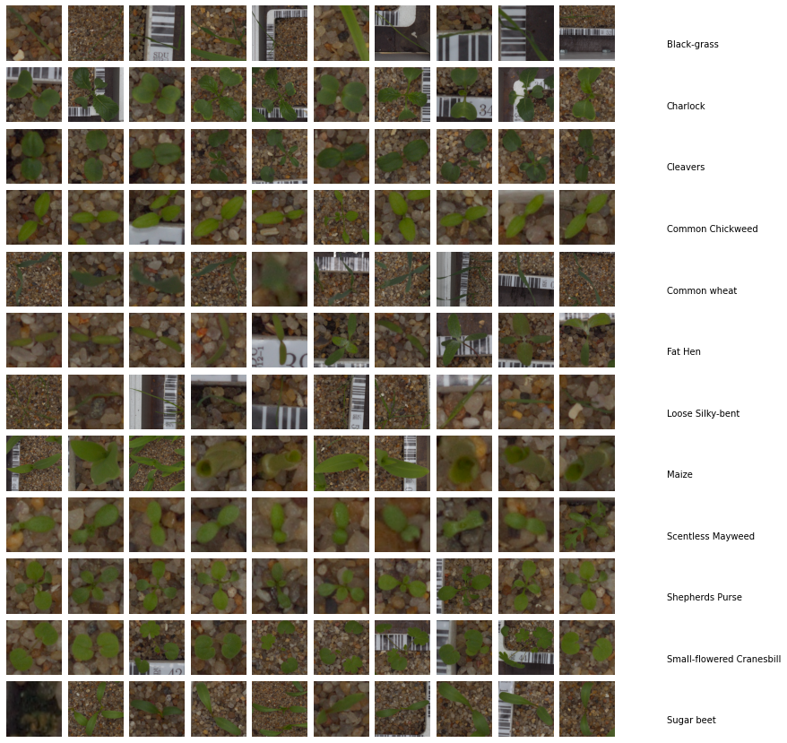

```python
fig = plt.figure(1, (20, 15))
grid = ImageGrid(fig, 111, nrows_ncols=(12, 10), axes_pad=0.1)

n_img_class = []
counter = 0
for idx, label in enumerate(label_names):
    paths = glob.glob(os.path.join("train", label, "*.png"))
    n_img_class.append([label, len(paths)])
    perm = np.random.choice(len(paths), size=10)

    title = True
    for ii in perm:
        ax = grid[counter]
        if title:
            ax.text(1800, 105, label, verticalalignment="center")
            title = False
        img = cv2.imread(paths[ii])
        img = cv2.resize(img, (150, 150))
        ax.axis("off")
        ax.imshow(cv2.cvtColor(img, cv2.COLOR_BGR2RGB))
        counter += 1

plt.show()
```

```python
img.shape
```

```
(150, 150, 3)
```

```python
#save the path into variable to use it easily next times.
TRAIN_FOLDER= "train"
```

```python
from glob import glob
images = []
classes=[]
missing=0
for class_folder_name in os.listdir(TRAIN_FOLDER):
    class_folder_path = os.path.join(TRAIN_FOLDER, class_folder_name)
    class_label = class_folder_name

    for image_path in glob(os.path.join(class_folder_path, "*.png")):
        image_bgr = cv2.imread(image_path, cv2.IMREAD_COLOR)
        if image_bgr is None: # if the file contain any missing value ignore it
          missing += 1
          continue
        images.append(image_bgr)

        classes.append(class_label)
```

```python
len(images)
```

```
4750
```

```python
# resize image
def resize_images(img):

  img = np.array(img).astype(np.uint8)
  #print(img.dtype)
  res = cv2.resize(img,(256,256), interpolation = cv2.INTER_CUBIC)
  return res

#save resized images into images.
images = [resize_images(img) for img in images]
```

```python
images[0].shape
```

```
(256, 256, 3)
```

```python
#see number of images in each label
images = np.array(images)
classes = np.array(classes)
print("images shape: ", images.shape)
print("classes shape: ", classes.shape)
```

```
images shape:  (4750, 256, 256, 3)
classes shape:  (4750,)
```

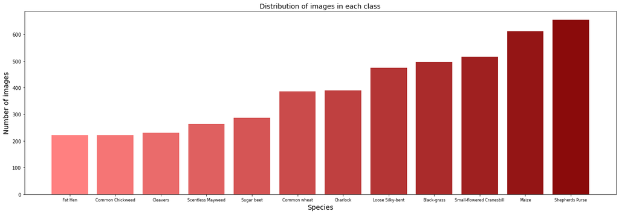

```python
values =[]
labels=[]
for label in set(classes):
  values.append(len(images[classes == label]))
  labels.append(label)

values.sort()

code=np.arange(0,13,1)
data_normalizer = mp.colors.Normalize()
color_map = mp.colors.LinearSegmentedColormap(
    "my_map",
    {
        "red": [(0, 1.0, 1.0),
                (1.0, .5, .5)],
        "green": [(0, 0.5, 0.5),
                  (1.0, 0, 0)],
        "blue": [(0, 0.50, 0.5),
                 (1.0, 0, 0)]
    }
)

fig, ax = plt.subplots(figsize=(22,7))
ax.bar(labels, values, color=color_map(data_normalizer(code)))
plt.xticks(fontsize = 8)
plt.yticks(fontsize = 10)
plt.xlabel("Species", fontsize = 14)
plt.ylabel("Number of images", fontsize = 14)
plt.title("Distribution of images in each class", fontsize=14)
plt.show()
```

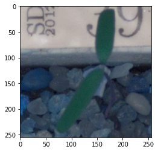

```python
plt.imshow(images[1804])
```

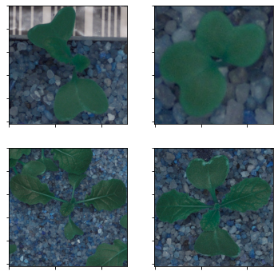

```python
def plot_for_class(label):
    nb_rows = 2
    nb_cols = 2
    fig, axs = plt.subplots(nb_rows, nb_cols, figsize=(6, 6))
    class_images =images[classes== label]
    n = 0
    for i in range(0, nb_rows):
        for j in range(0, nb_cols):
            axs[i, j].xaxis.set_ticklabels([])
            axs[i, j].yaxis.set_ticklabels([])
            axs[i, j].imshow(class_images[n])
            n += 1
plot_for_class("Charlock")
```

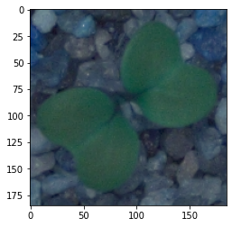

```python
#1da9ac0ba
img = cv2.imread("train/Charlock/1da9ac0ba.png")
plt.imshow(img)
```

## Image Pre-processing

**Converting images from RGB to HSV and applying mophological transformations**

```python
def create_mask_for_plant(image):
    image_hsv = cv2.cvtColor(image, cv2.COLOR_BGR2HSV)

    sensitivity = 35
    lower_hsv = np.array([60 - sensitivity, 100, 50])
    upper_hsv = np.array([60 + sensitivity, 255, 255])

    mask = cv2.inRange(image_hsv, lower_hsv, upper_hsv)
    kernel = cv2.getStructuringElement(cv2.MORPH_ELLIPSE, (11,11))
    mask = cv2.morphologyEx(mask, cv2.MORPH_CLOSE, kernel)

    return mask
```

**Applying Segmentation**

```python
def segment_plant(image):
    mask = create_mask_for_plant(image)
    output = cv2.bitwise_and(image, image, mask = mask)
    return output
```

**Applying Sharpening**

```python
def sharpen_image(image):
    image_blurred = cv2.GaussianBlur(image, (0, 0), 3)
    image_sharp = cv2.addWeighted(image, 1.5, image_blurred, -0.5, 0)
    return image_sharp
```

```python
# Combining all functions

def preprocess(img):
  image_segmented = segment_plant(img)
  image_sharpen = sharpen_image(image_segmented)
  return image_sharpen

for indx, image in enumerate(images):
  try:
    images[indx] = preprocess(image)

  except:
    print(indx)
    continue
```

**Viewing the pre-processed images**

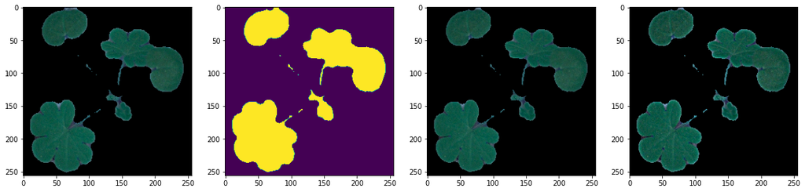

```python
images = np.array(images)
classes = np.array(classes)
image = images[classes == "Small-flowered Cranesbill"][40]

image_mask = create_mask_for_plant(image)
image_segmented = segment_plant(image)
image_sharpen = sharpen_image(image_segmented)

fig, axs = plt.subplots(1, 4, figsize=(20, 20))
axs[0].imshow(image)
axs[1].imshow(image_mask)
axs[2].imshow(image_segmented)
axs[3].imshow(image_sharpen)
```

```python
model_performance = pd.DataFrame(columns=['Model', 'Accuracy', 'Loss','Predicted Class'])
```

```python
number_of_columns = images[1].shape[0] * images[1].shape[1]
print(number_of_columns)
```

```
65536
```

```python
#for using colab
#from google.colab.patches import cv2_imshow
#img_pred = cv2.imread('/content/drive/MyDrive/****/Seedling - Prediction/Predict.png')
img_pred = cv2.imread('Predict.png')
img_pred_resize = cv2.resize(img_pred,(256,256), interpolation = cv2.INTER_CUBIC)
# cv2.imshow('Predict',img_pred_resize)
img_predict = np.expand_dims(img_pred_resize, axis=0)
print(f"The shape of image to be predicted is:'{img_pred.shape}'")
print(f"The shape of image to be predicted after expanding the dimensions is:'{img_predict.shape}'")
```

```
The shape of image to be predicted is:'(578, 578, 3)'
The shape of image to be predicted after expanding the dimensions is:'(1, 256, 256, 3)'
```

# Part 1 Q2 - Train tune and test AIML image classifier model using

## Supervised learning algorithms

**Label Encoding**

```python
enc = LabelEncoder()
y = enc.fit_transform(classes)

num_classes = len(np.unique(y))
num_classes
```

```
12
```

**Splitting Train and Test**

```python
X_train, X_test, y_train, y_test = train_test_split(images, y, test_size=0.3, random_state=0)
```

**Splitting Validation and Test**

```python
random_seed = 0
X_test, X_val, y_test, y_val = train_test_split(X_test,y_test, test_size = 0.5, random_state=random_seed)
```

**Shape of Feature Data**

```python
print(f"#### Shapes of Train, Test and Validation sets are: {X_train.shape},{X_test.shape},{X_val.shape}")
```

```
#### Shapes of Train, Test and Validation sets are: (3325, 256, 256, 3),(712, 256, 256, 3),(713, 256, 256, 3)
```

**Shape of Target Data**

```python
print(f"#### Shapes of Train, Test and Validation sets of Target are: {y_train.shape},{y_test.shape},{y_val.shape}")
```

```
#### Shapes of Train, Test and Validation sets of Target are: (3325,),(712,),(713,)
```

The dataset have over 65536 features for each image and only 3325 images total in train dataset. To use an SVM, our model of choice, the number of features needs to be reduced.

PCA is a way of linearly transforming the data such that most of the information in the data is contained within a smaller number of features called components.

```python
def flatten(X):
  Xr, Xg, Xb = [],[],[]
  for samples in X:
    r, g, b = cv2.split(samples)
    Xr.append(r.flatten())
    Xg.append(g.flatten())
    Xb.append(b.flatten())
  Xr = np.array(Xr)
  Xg = np.array(Xg)
  Xb = np.array(Xb)
  return (Xr, Xg, Xb)
```

```python
X_train_r, X_train_g, X_train_b = flatten(X_train)
X_test_r, X_test_g, X_test_b = flatten(X_test)
X_val_r, X_val_g, X_val_b = flatten(X_val)
```

```python
X_train_r.shape,X_train_g.shape,X_train_b.shape
```

```
((3325, 65536), (3325, 65536), (3325, 65536))
```

```python
X_test_r.shape, X_test_g.shape, X_test_b.shape,
```

```
((712, 65536), (712, 65536), (712, 65536))
```

```python
X_val_r.shape, X_val_g.shape, X_val_b.shape
```

```
((713, 65536), (713, 65536), (713, 65536))
```

**PCA**

```python
n_components = 500
X_train_pca_r = RandomizedPCA(n_components=n_components, whiten=True).fit(X_train_r)
X_train_pca_g = RandomizedPCA(n_components=n_components, whiten=True).fit(X_train_g)
X_train_pca_b = RandomizedPCA(n_components=n_components, whiten=True).fit(X_train_b)

X_test_pca_r = RandomizedPCA(n_components=n_components, whiten=True).fit(X_test_r)
X_test_pca_g = RandomizedPCA(n_components=n_components, whiten=True).fit(X_test_g)
X_test_pca_b = RandomizedPCA(n_components=n_components, whiten=True).fit(X_test_b)

X_val_pca_r = RandomizedPCA(n_components=n_components, whiten=True).fit(X_val_r)
X_val_pca_g = RandomizedPCA(n_components=n_components, whiten=True).fit(X_val_g)
X_val_pca_b = RandomizedPCA(n_components=n_components, whiten=True).fit(X_val_b)
```

```python
Xr_train_pca = X_train_pca_r.transform(X_train_r)
Xg_train_pca = X_train_pca_g.transform(X_train_g)
Xb_train_pca = X_train_pca_b.transform(X_train_b)

Xr_test_pca = X_test_pca_r.transform(X_test_r)
Xg_test_pca = X_test_pca_g.transform(X_test_g)
Xb_test_pca = X_test_pca_b.transform(X_test_b)

Xr_val_pca = X_val_pca_r.transform(X_val_r)
Xg_val_pca = X_val_pca_g.transform(X_val_g)
Xb_val_pca = X_val_pca_b.transform(X_val_b)
```

```python
print(X_train_pca_r.explained_variance_ratio_.sum(), X_train_pca_g.explained_variance_ratio_.sum(), X_train_pca_b.explained_variance_ratio_.sum())


print(X_test_pca_r.explained_variance_ratio_.sum(), X_test_pca_g.explained_variance_ratio_.sum(), X_test_pca_b.explained_variance_ratio_.sum())


print(X_val_pca_r.explained_variance_ratio_.sum(), X_val_pca_g.explained_variance_ratio_.sum(), X_val_pca_b.explained_variance_ratio_.sum())
```

```
0.8114884578528297 0.9066915985733783 0.8804897522172925
0.9562946206942236 0.9787573907747463 0.9711935131332328
0.9568108896572994 0.9789055315402337 0.9716010604611225
```

```python
X_train_pca = np.concatenate([Xr_train_pca,Xg_train_pca,Xb_train_pca], axis=1)
X_test_pca = np.concatenate([Xr_test_pca,Xg_test_pca,Xb_test_pca], axis=1)
X_val_pca = np.concatenate([Xr_val_pca,Xg_val_pca,Xb_val_pca], axis=1)
```

```python
X_train_pca.shape, y_train.shape,X_test_pca.shape, y_test.shape,X_val_pca.shape, y_val.shape
```

```
((3325, 1500), (3325,), (712, 1500), (712,), (713, 1500), (713,))
```

1. **SVM**

```python
param_grid = [
  {'C': [1, 10, 100, 1000], 'kernel': ['linear']},
  {'C': [1, 10, 100, 1000], 'gamma': [0.001, 0.0001], 'kernel': ['rbf']},
 ]
svc = SVC()
clf = GridSearchCV(svc, param_grid, verbose=10, n_jobs=-1)
clf.fit(X_train_pca, y_train)
```

```
Fitting 5 folds for each of 12 candidates, totalling 60 fits
```

```
GridSearchCV(estimator=SVC(), n_jobs=-1,
             param_grid=[{'C': [1, 10, 100, 1000], 'kernel': ['linear']},
                         {'C': [1, 10, 100, 1000], 'gamma': [0.001, 0.0001],
                          'kernel': ['rbf']}],
             verbose=10)
```

```python
X_train.shape[0]
```

```
3325
```

```python
y_train.shape[0]
```

```
3325
```

```python
svm_score = clf.score(X_val_pca, y_val)
```

**Save the model**

```python
import pickle
```

```python
print("Saved to local disk")
# create an iterator object with write permission - model.pkl
with open('SVM_model_pkl', 'wb') as files:
    pickle.dump(clf, files)
```

```
Saved to local disk
```

```python
# load saved model
print("Loaded from local disk")
with open('SVM_model_pkl' , 'rb') as f:
    clf = pickle.load(f)
```

```
Loaded from local disk
```

```python
y_pred = clf.predict(X_test_pca)
svm_accuracy = metrics.accuracy_score(y_test, y_pred)
```

```python
pred_img = np.squeeze(img_predict, axis=0)
X_pred_r, X_pred_g, X_pred_b = cv2.split(pred_img)
```

```python
X_pred_pca_r = X_train_pca_r.transform(np.expand_dims(X_pred_r.flatten(), axis=0))
X_pred_pca_g = X_train_pca_g.transform(np.expand_dims(X_pred_g.flatten(), axis=0))
X_pred_pca_b = X_train_pca_b.transform(np.expand_dims(X_pred_b.flatten(), axis=0))

X_pred_pca = np.concatenate([X_pred_pca_r,X_pred_pca_g,X_pred_pca_b], axis=1)
```

```python
pred_svm = clf.predict(X_pred_pca)[0]

print(f"The predicted label is:'{pred_svm}'")
```

```
The predicted label is:'7'
```

```python
model_performance = model_performance.append({'Model':'SVM',
                                              'Accuracy': svm_accuracy,
                                              'Loss': 'NA',
                                              'Predicted Class': pred_svm

                                              }, ignore_index=True)

model_performance
```

|  | Model | Accuracy | Loss | Predicted Class |
| --- | --- | --- | --- | --- |
| 0 | SVM | 0.297753 | NA | 7 |

1. **Random Forest**

```python
param_grid=[
            {'n_estimators':[100,200],
             'min_samples_leaf':[2,3]}
           ]
rf = RandomForestClassifier()
clf = GridSearchCV(rf, param_grid, verbose=10, n_jobs=-1)
clf.fit(X_train_pca,y_train)
```

```
Fitting 5 folds for each of 4 candidates, totalling 20 fits
```

```
GridSearchCV(estimator=RandomForestClassifier(), n_jobs=-1,
             param_grid=[{'min_samples_leaf': [2, 3],
                          'n_estimators': [100, 200]}],
             verbose=10)
```

**Save the model**

```python
import pickle
print("Saved to local disk")
# create an iterator object with write permission - model.pkl
with open('RF_model_pkl', 'wb') as files:
    pickle.dump(clf, files)
```

```python
# load saved model
print("Loaded from local disk")
with open('RF_model_pkl' , 'rb') as f:
    clf_rf = pickle.load(f)
```

```
Loaded from local disk
```

```python
rf_score = clf_rf.score(X_val_pca, y_val)
y_pred = clf_rf.predict(X_test_pca)
rf_accuracy = metrics.accuracy_score(y_test, y_pred)
pred_rf = clf_rf.predict(X_pred_pca)[0]
print(f"The predicted label is:'{pred_rf}'")
```

```
The predicted label is:'10'
```

```python
model_performance = model_performance.append({'Model':'RF',
                                              'Accuracy': rf_accuracy,
                                              'Loss': 'NA',
                                              'Predicted Class': pred_rf

                                              }, ignore_index=True)

model_performance
```

|  | Model | Accuracy | Loss | Predicted Class |
| --- | --- | --- | --- | --- |
| 0 | SVM | 0.297753 | NA | 7 |
| 1 | RF | 0.428371 | NA | 10 |

**3. Decision Tree**

```python
from sklearn.tree import DecisionTreeClassifier
param_grid = [
              {'max_leaf_nodes': list(range(2, 100)),
               'min_samples_split': [2, 3, 4]}
              ]
dt = DecisionTreeClassifier()
clf = GridSearchCV(dt, param_grid, verbose=10, n_jobs=-1)
clf.fit(X_train_pca,y_train)
```

```
Fitting 5 folds for each of 294 candidates, totalling 1470 fits
```

```
GridSearchCV(estimator=DecisionTreeClassifier(), n_jobs=-1,
             param_grid=[{'max_leaf_nodes': [2, 3, 4, 5, 6, 7, 8, 9, 10, 11, 12,
                                             13, 14, 15, 16, 17, 18, 19, 20, 21,
                                             22, 23, 24, 25, 26, 27, 28, 29, 30,
                                             31, ...],
                          'min_samples_split': [2, 3, 4]}],
             verbose=10)
```

**Save the model**

```python
# import pickle
print("Saved to local disk")
# create an iterator object with write permission - model.pkl
with open('DT_model_pkl', 'wb') as files:
    pickle.dump(clf, files)
```

```python
# load saved model
print("Loaded from local disk")
with open('DT_model_pkl' , 'rb') as f:
    clf_DT = pickle.load(f)
```

```
Loaded from local disk
```

```python
dt_score = clf_DT.score(X_val_pca, y_val)
y_pred = clf_DT.predict(X_test_pca)
dt_accuracy = metrics.accuracy_score(y_test, y_pred)
pred_dt = clf_DT.predict(X_pred_pca)[0]
print(f"The predicted label is:'{pred_dt}'")
```

```
The predicted label is:'1'
```

```python
model_performance = model_performance.append({'Model':'DT',
                                              'Accuracy': dt_accuracy,
                                              'Loss': 'NA',
                                              'Predicted Class': pred_dt

                                              }, ignore_index=True)

model_performance
```

|  | Model | Accuracy | Loss | Predicted Class |
| --- | --- | --- | --- | --- |
| 0 | SVM | 0.297753 | NA | 7 |
| 1 | RF | 0.428371 | NA | 10 |
| 2 | DT | 0.380618 | NA | 1 |

# *Classification using Artificial Neural Network (ANN)*

```python
import itertools

import tensorflow
from tensorflow.python.keras.layers import Activation,Dense, Dropout, InputLayer, BatchNormalization, Flatten
from tensorflow.python.keras.layers import GlobalAveragePooling2D, Conv2D, MaxPool2D, GlobalMaxPool2D
from tensorflow.python.keras.models import Sequential
from tensorflow.python.keras.wrappers.scikit_learn import KerasRegressor
from sklearn.datasets import load_files
from sklearn.preprocessing import StandardScaler
from sklearn.metrics import mean_absolute_error
from sklearn.metrics import mean_squared_error
from sklearn.metrics import confusion_matrix, classification_report
from sklearn.model_selection import StratifiedKFold
from keras.utils.np_utils import to_categorical # convert to one-hot-encoding
from keras.utils import np_utils
from tensorflow.keras.models import Sequential
from keras.layers import Dense, Dropout, Flatten, Conv2D, MaxPool2D, GlobalMaxPooling2D,MaxPooling2D
from keras.callbacks import ModelCheckpoint, ReduceLROnPlateau,EarlyStopping
from tensorflow.keras.optimizers import RMSprop
from tensorflow.keras.preprocessing.image import ImageDataGenerator
from tensorflow.keras.optimizers import Adam
from tensorflow.keras import optimizers
from tqdm import tqdm
from PIL import ImageFile
from keras.preprocessing import image
from keras.preprocessing.image import ImageDataGenerator, array_to_img, img_to_array, load_img
```

```python
# from sklearn.preprocessing import LabelBinarizer
# enc = LabelBinarizer()
# y2 = enc.fit_transform(classes)
```

```python
# for y
y_labelencoder = LabelEncoder ()
y2 = y_labelencoder.fit_transform (y)
print (y2)
```

```
[ 0  0  0 ... 11 11 11]
```

```python
images = images.astype('float32') / 255.0
```

```python
images.shape
```

```
(4750, 256, 256, 3)
```

```python
from sklearn.model_selection import train_test_split
X_train, X_test, y_train, y_test = train_test_split(images, y2, test_size=0.3, random_state=50)
```

```python
random_seed = 2
from sklearn.model_selection import train_test_split
X_test, X_val, y_test, y_val = train_test_split(X_test,y_test, test_size = 0.5, random_state=random_seed)
```

```python
X_train.shape,y_train.shape
```

```
((3325, 256, 256, 3), (3325,))
```

```python
X_val.shape,y_val.shape
```

```
((713, 256, 256, 3), (713,))
```

```python
X_test.shape,y_test.shape
```

```
((712, 256, 256, 3), (712,))
```

```python
# Develop a sequential model using tensorflow keras
import keras
import tensorflow as tf
model = keras.Sequential([
    keras.layers.Flatten(input_shape=(256,256,3)),
    keras.layers.BatchNormalization(),
    keras.layers.Dense(1024, activation='relu'),
    keras.layers.Dropout(0.2),

    keras.layers.BatchNormalization(),
    keras.layers.Dense(512, activation='relu'),
    keras.layers.Dropout(0.2),

    keras.layers.BatchNormalization(),
    keras.layers.Dense(256, activation='relu'),
    keras.layers.Dropout(0.2),

    keras.layers.BatchNormalization(),
    keras.layers.Dense(12, activation= "softmax")
])
```

```python
model.summary()
```

```
Model: "sequential_2"
_________________________________________________________________
 Layer (type)                Output Shape              Param #
=================================================================
 flatten (Flatten)           (None, 196608)            0

 batch_normalization (BatchN  (None, 196608)           786432
 ormalization)

 dense_4 (Dense)             (None, 1024)              201327616

 dropout_10 (Dropout)        (None, 1024)              0

 batch_normalization_1 (Batc  (None, 1024)             4096
 hNormalization)

 dense_5 (Dense)             (None, 512)               524800

 dropout_11 (Dropout)        (None, 512)               0

 batch_normalization_2 (Batc  (None, 512)              2048
 hNormalization)

 dense_6 (Dense)             (None, 256)               131328

 dropout_12 (Dropout)        (None, 256)               0

 batch_normalization_3 (Batc  (None, 256)              1024
 hNormalization)

 dense_7 (Dense)             (None, 12)                3084

=================================================================
Total params: 202,780,428
Trainable params: 202,383,628
Non-trainable params: 396,800
_________________________________________________________________
```

```python
# Compute the model parameters
opt = tensorflow.keras.optimizers.Adam(lr=0.00001)
loss='sparse_categorical_crossentropy'
metrics=['accuracy']

model.compile(optimizer = opt, loss = loss, metrics = metrics)
```

**Apply ModelCheckpoint and Earlystopping**

```python
from keras.callbacks import ModelCheckpoint,EarlyStopping
filestore = 'saved_models/ANN/weights.{epoch:02d}-{val_loss:.2f}.hdf5'
checkpointer = ModelCheckpoint(filepath= filestore,monitor='val_loss',mode='auto',
                               verbose=1, save_best_only=True)

earlystop = EarlyStopping(monitor = 'val_loss',min_delta = 0,patience = 3, verbose = 1,restore_best_weights = True)

callbacks_list = [checkpointer,earlystop]
```

```python
model.fit(X_train, y_train, epochs = 50, validation_data = (X_val,y_val),batch_size = 32,callbacks=callbacks_list)
```

```
Epoch 00001: val_loss improved from inf to 2.24899, saving model to saved_models/ANN\weights.01-2.25.hdf5
Epoch 00002: val_loss improved from 2.24899 to 1.97087, saving model to saved_models/ANN\weights.02-1.97.hdf5
Epoch 00003: val_loss improved from 1.97087 to 1.60022, saving model to saved_models/ANN\weights.03-1.60.hdf5
Epoch 00004: val_loss improved from 1.60022 to 1.27015, saving model to saved_models/ANN\weights.04-1.27.hdf5
Epoch 00005: val_loss improved from 1.27015 to 1.10984, saving model to saved_models/ANN\weights.05-1.11.hdf5
Epoch 00006: val_loss improved from 1.10984 to 1.04459, saving model to saved_models/ANN\weights.06-1.04.hdf5
Epoch 00007: val_loss improved from 1.04459 to 1.00316, saving model to saved_models/ANN\weights.07-1.00.hdf5
Epoch 00008: val_loss improved from 1.00316 to 1.00301, saving model to saved_models/ANN\weights.08-1.00.hdf5
Epoch 00009: val_loss did not improve from 1.00301
Epoch 00010: val_loss did not improve from 1.00301
Epoch 00011: val_loss did not improve from 1.00301
Restoring model weights from the end of the best epoch: 8.
Epoch 00011: early stopping
```

```
<keras.callbacks.History at 0x19c97ce0940>
```

```python
model.save('saved_models/ANN_Model/ANN.h5')
```

```python
new_model_ann = tensorflow.keras.models.load_model('saved_models/ANN_Model/ANN.h5')
```

```python
new_model_ann.summary()
```

```
Model: "sequential"
_________________________________________________________________
 Layer (type)                Output Shape              Param #
=================================================================
 flatten (Flatten)           (None, 196608)            0

 batch_normalization (BatchN  (None, 196608)           786432
 ormalization)

 dense (Dense)               (None, 1024)              201327616

 dropout (Dropout)           (None, 1024)              0

 batch_normalization_1 (Batc  (None, 1024)             4096
 hNormalization)

 dense_1 (Dense)             (None, 512)               524800

 dropout_1 (Dropout)         (None, 512)               0

 batch_normalization_2 (Batc  (None, 512)              2048
 hNormalization)

 dense_2 (Dense)             (None, 256)               131328

 dropout_2 (Dropout)         (None, 256)               0

 batch_normalization_3 (Batc  (None, 256)              1024
 hNormalization)

 dense_3 (Dense)             (None, 12)                3084

=================================================================
Total params: 202,780,428
Trainable params: 202,383,628
Non-trainable params: 396,800
_________________________________________________________________
```

```python
accuracy=new_model_ann.evaluate(x=X_val,y=y_val,batch_size=32)
print("Loss of the model: {} , Accuracy of Model :{} ".format(accuracy[0],accuracy[1]))
```

```
Loss of the model: 1.003006100654602 , Accuracy of Model :0.6521739363670349
```

```python
ann_predict = np.argmax(new_model_ann.predict(img_predict))
```

```python
model_performance = model_performance.append({'Model':'ANN',
                                              'Accuracy': accuracy[1],
                                              'Loss': accuracy[0],
                                              'Predicted Class': ann_predict
                                              }, ignore_index=True)

model_performance
```

|  | Model | Accuracy | Loss | Predicted Class |
| --- | --- | --- | --- | --- |
| 0 | SVM | 0.297753 | NA | 7 |
| 1 | RF | 0.428371 | NA | 10 |
| 2 | DT | 0.380618 | NA | 1 |
| 3 | ANN | 0.652174 | 1.003006 | 1 |

# *Classification using Convolution Neural Network (CNN)*

```python
import itertools

import tensorflow
from tensorflow.python.keras.layers import Dense, Dropout, InputLayer, BatchNormalization, Flatten
from tensorflow.python.keras.layers import GlobalAveragePooling2D, Conv2D, MaxPool2D, GlobalMaxPool2D
from tensorflow.python.keras.models import Sequential
from tensorflow.python.keras.wrappers.scikit_learn import KerasRegressor
from sklearn.datasets import load_files
from sklearn.preprocessing import StandardScaler
from sklearn.metrics import mean_absolute_error
from sklearn.metrics import mean_squared_error
from sklearn.metrics import confusion_matrix, classification_report
from sklearn.model_selection import StratifiedKFold
from keras.utils.np_utils import to_categorical # convert to one-hot-encoding
from keras.utils import np_utils
from tensorflow.keras.models import Sequential
from keras.layers import Dense, Dropout, Flatten, Conv2D, MaxPool2D, GlobalMaxPooling2D,MaxPooling2D
from keras.callbacks import ModelCheckpoint, ReduceLROnPlateau,EarlyStopping
from tensorflow.keras.optimizers import RMSprop
from tensorflow.keras.preprocessing.image import ImageDataGenerator
from tensorflow.keras.optimizers import Adam
from tqdm import tqdm
from PIL import ImageFile
from keras.preprocessing import image
from keras.preprocessing.image import ImageDataGenerator, array_to_img, img_to_array, load_img
```

```python
def load_dataset(path):
    data=load_files(path)
    plant_files=np.array(data['filenames'])
    plant_targets=np_utils.to_categorical(np.array(data['target']),12)
    return plant_files,plant_targets

print('Loading Train Files and Targets')
train_files, train_targets = load_dataset('C:/Users/AI_SG/Documents/Upendran/Course/python/Projects/Computer Vision/PROJECT 1/train')
print('Loading Complete!')
print('There are %d training plant images.' % len(train_files))
```

```
Loading Train Files and Targets
Loading Complete!
There are 4750 training plant images.
```

```python
def path_to_tensor(img_path):
    # loads RGB image as PIL.Image.Image type
    img = image.load_img(img_path, target_size=(256, 256))
    # convert PIL.Image.Image type to 3D tensor with shape (256, 256, 3)
    x = image.img_to_array(img)
    # convert 3D tensor to 4D tensor with shape (1, 256, 256, 3) and return 4D tensor
    return np.expand_dims(x, axis=0)

def paths_to_tensor(img_paths):
    list_of_tensors = [path_to_tensor(img_path) for img_path in tqdm(img_paths)]
    return np.vstack(list_of_tensors)
```

```python
# pre-process the data for Keras
train_tensors = paths_to_tensor(train_files).astype('float32')/255
```

```python
train_tensors.shape
```

```
(4750, 256, 256, 3)
```

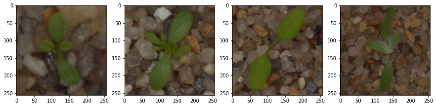

```python
fig, axs = plt.subplots(1, 4, figsize=(15,15))

axs[0].imshow(train_tensors[0])
axs[1].imshow(train_tensors[10])
axs[2].imshow(train_tensors[42])
axs[3].imshow(train_tensors[650])
```

```python
seed = 31
np.random.seed(seed)



# Split the train and the validation set
train_tensors, val_train, train_targets, val_targets = train_test_split(train_tensors,
                                              train_targets,
                                              test_size=0.15,
                                              random_state=seed
                                             )

print(train_tensors.shape)
print(val_train.shape)
print(train_targets.shape)
print(val_targets.shape)
```

```
(4037, 256, 256, 3)
(713, 256, 256, 3)
(4037, 12)
(713, 12)
```

```python
cnnmodel= Sequential()

cnnmodel.add(Conv2D(filters = 16, kernel_size = (5,5),padding = 'Same', activation ='relu',input_shape=(256,256,3)))
cnnmodel.add(MaxPooling2D(pool_size=2))
cnnmodel.add(Dropout(0.1))

cnnmodel.add(Conv2D(filters = 32, kernel_size = (5,5),padding = 'Same', activation ='relu'))
cnnmodel.add(Conv2D(filters = 32, kernel_size = (5,5),padding = 'Same', activation ='relu'))
cnnmodel.add(MaxPooling2D(pool_size=2))
cnnmodel.add(Dropout(0.1))

cnnmodel.add(Conv2D(filters = 64, kernel_size = (3,3),padding = 'Same', activation ='relu'))
cnnmodel.add(Conv2D(filters = 64, kernel_size = (3,3),padding = 'Same', activation ='relu'))
cnnmodel.add(MaxPooling2D(pool_size=2))
cnnmodel.add(Dropout(0.1))


cnnmodel.add(Conv2D(filters = 128, kernel_size = (3,3),padding = 'Same', activation ='relu'))
cnnmodel.add(Conv2D(filters = 128, kernel_size = (3,3),padding = 'Same', activation ='relu'))
cnnmodel.add(MaxPooling2D(pool_size=2))
cnnmodel.add(Dropout(0.1))

cnnmodel.add(GlobalAveragePooling2D())

cnnmodel.add(Dense(256,activation='relu'))
cnnmodel.add(Dropout(0.1))
cnnmodel.add(Dense(12,activation='softmax'))

cnnmodel.summary()
```

```
Model: "sequential_3"
_________________________________________________________________
 Layer (type)                Output Shape              Param #
=================================================================
 conv2d_14 (Conv2D)          (None, 256, 256, 16)      1216

 max_pooling2d_8 (MaxPooling  (None, 128, 128, 16)     0
 2D)

 dropout_13 (Dropout)        (None, 128, 128, 16)      0

 conv2d_15 (Conv2D)          (None, 128, 128, 32)      12832

 conv2d_16 (Conv2D)          (None, 128, 128, 32)      25632

 max_pooling2d_9 (MaxPooling  (None, 64, 64, 32)       0
 2D)

 dropout_14 (Dropout)        (None, 64, 64, 32)        0

 conv2d_17 (Conv2D)          (None, 64, 64, 64)        18496

 conv2d_18 (Conv2D)          (None, 64, 64, 64)        36928

 max_pooling2d_10 (MaxPoolin  (None, 32, 32, 64)       0
 g2D)

 dropout_15 (Dropout)        (None, 32, 32, 64)        0

 conv2d_19 (Conv2D)          (None, 32, 32, 128)       73856

 conv2d_20 (Conv2D)          (None, 32, 32, 128)       147584

 max_pooling2d_11 (MaxPoolin  (None, 16, 16, 128)      0
 g2D)

 dropout_16 (Dropout)        (None, 16, 16, 128)       0

 module_wrapper_2 (ModuleWra  (None, 128)              0
 pper)

 dense_8 (Dense)             (None, 256)               33024

 dropout_17 (Dropout)        (None, 256)               0

 dense_9 (Dense)             (None, 12)                3084

=================================================================
Total params: 352,652
Trainable params: 352,652
Non-trainable params: 0
_________________________________________________________________
```

```python
optimizer = RMSprop(learning_rate=0.001, rho=0.9, epsilon=1e-08, decay=0.0)
cnnmodel.compile(optimizer = optimizer, loss = 'categorical_crossentropy', metrics = ["accuracy"])
```

```python
# !pip install cython
```

```python
from tensorflow.keras.callbacks import ModelCheckpoint,EarlyStopping
# filestorec = 'saved_models/cnn/weights.{epoch:02d}-{val_loss:.2f}.hdf5'
# checkpointerc = ModelCheckpoint(filepath= filestorec,monitor='val_loss',mode='auto',
#                                verbose=1, save_best_only=True)

earlystopc = EarlyStopping(monitor = 'val_loss',min_delta = 0,patience = 3, verbose = 1,restore_best_weights = True)

callbacks_listc = [earlystopc]
```

```python
history = cnnmodel.fit(train_tensors, train_targets, epochs = 25,callbacks=callbacks_listc, validation_data = (val_train,val_targets),batch_size = 64)
```

```
Epoch 00022: early stopping
```

```python
# cnnmodel.save("./Model_CNN_PlantSeedling_ImageClassification.h5")
```

```python
cnnmodel.save_weights('saved_models/CNNweights.hdf5')
```

```python
accuracy=cnnmodel.evaluate(x=val_train,y=val_targets,batch_size=32)
print("Loss of the model: {} , Accuracy of Model :{} ".format(accuracy[0],accuracy[1]))
```

```
Loss of the model: 2.4845259189605713 , Accuracy of Model :0.06591865420341492
```

```python
cnn_predict = np.argmax(cnnmodel.predict(img_predict))
```

```python
model_performance = model_performance.append({'Model':'CNN',
                                              'Accuracy': accuracy[1],
                                              'Loss': accuracy[0],
                                              'Predicted Class': cnn_predict
                                              }, ignore_index=True)

model_performance
```

|  | Model | Accuracy | Loss | Predicted Class |
| --- | --- | --- | --- | --- |
| 0 | SVM | 0.297753 | NA | 7 |
| 1 | RF | 0.428371 | NA | 10 |
| 2 | DT | 0.380618 | NA | 1 |
| 3 | ANN | 0.652174 | 1.003006 | 1 |
| 4 | CNN | 0.065919 | 2.484526 | 9 |

## Fine Tuning

```python
learning_rate_reduction = ReduceLROnPlateau(monitor='val_accuracy',
                                            patience=3,
                                            verbose=1,
                                            factor=0.5,
                                            min_lr=0.0001)
```

```python
datagen = ImageDataGenerator(
        featurewise_center=False,  # set input mean to 0 over the dataset
        samplewise_center=False,  # set each sample mean to 0
        featurewise_std_normalization=False,  # divide inputs by std of the dataset
        samplewise_std_normalization=False,  # divide each input by its std
        zca_whitening=False,  # apply ZCA whitening
        rotation_range=10,  # randomly rotate images in the range (degrees, 0 to 180)
        zoom_range = 0.1, # Randomly zoom image
        width_shift_range=0.1,  # randomly shift images horizontally (fraction of total width)
        height_shift_range=0.1,  # randomly shift images vertically (fraction of total height)
        horizontal_flip=False,  # randomly flip images
        vertical_flip=False)  # randomly flip images


datagen.fit(train_tensors)
```

```python
from tensorflow.keras.callbacks import ModelCheckpoint,EarlyStopping
# filestorec1 = 'saved_models/cnn_rev/weights.{epoch:02d}-{val_loss:.2f}.hdf5'
# checkpointerc1 = ModelCheckpoint(filepath= filestorec1,monitor='val_loss',mode='auto',
#                                verbose=1, save_best_only=True)

earlystopc1 = EarlyStopping(monitor = 'val_loss',min_delta = 0,patience = 3, verbose = 1,restore_best_weights = True)

callbacks_listc1 = [learning_rate_reduction,earlystopc1]
```

```python
batch = 32



history = cnnmodel.fit_generator(datagen.flow(train_tensors,train_targets,batch_size=batch),epochs = 30, validation_data = (val_train,val_targets),
                              verbose = 1, steps_per_epoch=train_tensors.shape[0] // batch
                              , callbacks=callbacks_listc1)
```

```
Epoch 00023: ReduceLROnPlateau reducing learning rate to 0.0005000000237487257.
Restoring model weights from the end of the best epoch: 20.
Epoch 00023: early stopping
```

```python
!mkdir -p saved_model_v1
cnnmodel.save('saved_models/my_model')
```

```
INFO:tensorflow:Assets written to: saved_models/my_model\assets
```

```python
cnnmodel.save_weights('saved_models/CNNweights_revisied.hdf5')
```

```python
cnnmodel.load_weights('saved_models/CNNweights_revisied.hdf5')
accuracy=cnnmodel.evaluate(x=val_train,y=val_targets,batch_size=32)
print("Loss of the model: {} , Accuracy of Model :{} ".format(accuracy[0],accuracy[1]))
```

```
Loss of the model: 0.43344438076019287 , Accuracy of Model :0.8457223176956177
```

```python
dataug_cnn_predict = np.argmax(cnnmodel.predict(img_predict))
```

```python
model_performance = model_performance.append({'Model':'Data_Aug_CNN',
                                              'Accuracy': accuracy[1],
                                              'Loss': accuracy[0],
                                              'Predicted Class': dataug_cnn_predict
                                              }, ignore_index=True)

model_performance
```

|  | Model | Accuracy | Loss | Predicted Class |
| --- | --- | --- | --- | --- |
| 0 | SVM | 0.297753 | NA | 7 |
| 1 | RF | 0.428371 | NA | 10 |
| 2 | DT | 0.380618 | NA | 1 |
| 3 | ANN | 0.652174 | 1.003006 | 1 |
| 4 | CNN | 0.065919 | 2.484526 | 9 |
| 5 | Data_Aug_CNN | 0.845722 | 0.433444 | 11 |

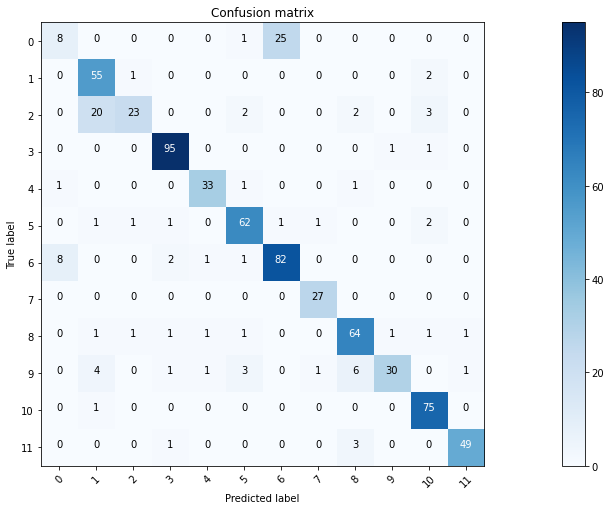

```python
from sklearn.metrics import confusion_matrix
import itertools
plt.subplots(figsize=(22,7)) #set the size of the plot

def plot_confusion_matrix(cm, classes,
                          normalize=False,
                          title='Confusion matrix',
                          cmap=plt.cm.Blues):
    """
    This function prints and plots the confusion matrix.
    Normalization can be applied by setting `normalize=True`.
    """
    plt.imshow(cm, interpolation='nearest', cmap=cmap)
    plt.title(title)
    plt.colorbar()
    tick_marks = np.arange(len(classes))
    plt.xticks(tick_marks, classes, rotation=45)
    plt.yticks(tick_marks, classes)

    if normalize:
        cm = cm.astype('float') / cm.sum(axis=1)[:, np.newaxis]

    thresh = cm.max() / 2.
    for i, j in itertools.product(range(cm.shape[0]), range(cm.shape[1])):
        plt.text(j, i, cm[i, j],
                 horizontalalignment="center",
                 color="white" if cm[i, j] > thresh else "black")

    plt.tight_layout()
    plt.ylabel('True label')
    plt.xlabel('Predicted label')

# Predict the values from the validation dataset
Y_pred = cnnmodel.predict(val_train)
# Convert predictions classes to one hot vectors
Y_pred_classes = np.argmax(Y_pred,axis = 1)
# Convert validation observations to one hot vectors
Y_true = np.argmax(val_targets,axis = 1)
# compute the confusion matrix
confusion_mtx = confusion_matrix(Y_true, Y_pred_classes)
# plot the confusion matrix
plot_confusion_matrix(confusion_mtx, classes = range(12))
```

[output not shown]

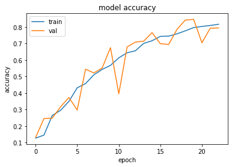

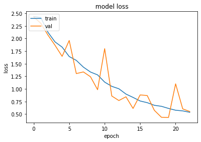

```python
# list all data in history
print(history.history.keys())
# summarize history for accuracy
plt.plot(history.history['accuracy'])
plt.plot(history.history['val_accuracy'])
plt.title('model accuracy')
plt.ylabel('accuracy')
plt.xlabel('epoch')
plt.legend(['train', 'val'], loc='upper left')
plt.show()
# summarize history for loss
plt.plot(history.history['loss'])
plt.plot(history.history['val_loss'])
plt.title('model loss')
plt.ylabel('loss')
plt.xlabel('epoch')
plt.legend(['train', 'val'], loc='upper left')
plt.show()
```

```python
def plant_seed_classification(image):

    image = path_to_tensor(image).astype('float32')/255

    new_model = tensorflow.keras.models.load_model('saved_models/my_model')

    # load weights into new model
    new_model.load_weights("saved_models/CNNweights_revisied.hdf5")
    print("Loaded model from disk")

    prediction = new_model.predict(image)

    print('The predicted Class of the image is {}'.format(np.argmax(prediction)))
    INV_CLASS = {
    0: 'Black-grass',
    1: 'Charlock',
    2: 'Cleavers',
    3: 'Common Chickweed',
    4: 'Common wheat',
    5: 'Fat Hen',
    6: 'Loose Silky-bent',
    7: 'Maize',
    8: 'Scentless Mayweed',
    9: 'Shepherds Purse',
    10: 'Small-flowered Cranesbill',
    11: 'Sugar beet'
     }

    print('The class of the plant is',[INV_CLASS[np.argmax(prediction)] ])
```

```python
plant_seed_classification('Predict.png')
```

```
Loaded model from disk
The predicted Class of the image is 7
The class of the plant is ['Maize']
```

## Part 1 Q3 Compare the results from the above step along with your detailed observations on the best performing algorithm and why/how it outperforms other algorithms in this case

```python
model_performance
```

|  | Model | Accuracy | Loss | Predicted Class |
| --- | --- | --- | --- | --- |
| 0 | SVM | 0.297753 | NA | 7 |
| 1 | RF | 0.428371 | NA | 10 |
| 2 | DT | 0.380618 | NA | 1 |
| 3 | ANN | 0.652174 | 1.003006 | 1 |
| 4 | CNN | 0.065919 | 2.484526 | 9 |
| 5 | Data_Aug_CNN | 0.845722 | 0.433444 | 11 |

> Also we got good perforamnce in Artifical neural networks 65%

> Supervised Learning model performance falls below 50%

**The reason for 84% in CNN is --> Data Augumentation. We have got small dataset of images 4750 images of plant. when we tried with data augumentation it has trained with large dataset.**

### We choose CNN with DataAugumentation is the best model for this process

## Part 1 Q4 Pickle the best performing mode

```python
!mkdir -p saved_models_v1
cnnmodel.save('saved_models_v1/my_model')


#  Pickle weights to HDF5
cnnmodel.save_weights("cnn_model_final_pkl.h5")
print("Saved model to disk")
```

```
INFO:tensorflow:Assets written to: saved_models_v1/my_model\assets
Saved model to disk
```

```python
# load saved file and create model

Final_model = tensorflow.keras.models.load_model('saved_models_v1/my_model')

# # load weights into new model
Final_model.load_weights("cnn_model_final_pkl.h5")
print("Loaded model from disk")
```

```
Loaded model from disk
```

```python
# Evaluate
Final_model.compile(loss='mse', optimizer='adam', metrics=['accuracy'])
score = Final_model.evaluate(val_train,val_targets, verbose=1)
print("%s: %.2f%%" % (Final_model.metrics_names[1], score[1]*100))
```

```
accuracy: 84.57%
```

## Part 1 Q5 Import the the test image [ from the “ Prediction” folder ] to predict the class. Display the image. Use the best trained image classifier model to predict the class.

```python
INV_CLASS = {
    0: 'Black-grass',
    1: 'Charlock',
    2: 'Cleavers',
    3: 'Common Chickweed',
    4: 'Common wheat',
    5: 'Fat Hen',
    6: 'Loose Silky-bent',
    7: 'Maize',
    8: 'Scentless Mayweed',
    9: 'Shepherds Purse',
    10: 'Small-flowered Cranesbill',
    11: 'Sugar beet'
     }
```

```python
accuracy=Final_model.evaluate(x=val_train,y=val_targets,batch_size=32)
print("Loss of the model: {} , Accuracy of Model :{} ".format(accuracy[0],accuracy[1]))
prediction_result = np.argmax(Final_model.predict(img_predict))
```

```
Loss of the model: 0.0186283178627491 , Accuracy of Model :0.8457223176956177
```

```python
model = pd.DataFrame(columns=['Model', 'Accuracy', 'Loss','Predicted Class','Predicted Labels'])
```

```python
model = model.append({'Model':'CNN Model with Data Augumentation',
                                              'Accuracy': accuracy[1]*100,
                                              'Loss': accuracy[0],
                                              'Predicted Class': prediction_result,
                                              'Predicted Labels':INV_CLASS[prediction_result]
                                              }, ignore_index=True)

model
```

|  | Model | Accuracy | Loss | Predicted Class | Predicted Labels |
| --- | --- | --- | --- | --- | --- |
| 0 | CNN Model with Data Augumentation | 84.572232 | 0.018628 | 11 | Sugar beet |